# Analyse Factorielle des Correspondances : Analyse de Gradients Floristiques

Gaspar Massiot

6/25/2021

```r
rm(list = ls())
library("knitr") # pour avoir un format table dans les sorties
library("ggplot2") # pour avoir de "beaux"" graphiques
library("FactoMineR") # pour effectuer l'ACP
library("factoextra") # pour extraire et visualiser les résultats issus de FactoMineR
library("corrplot") # pour avoir une représentation des corrélations
library("dplyr")
library("tidyr")
```

## Présentation des données

Le jeu de données a été mis à disposition du public par Jongman et al. (1987). Il est constitué de relevés floristiques effectués dans des formations végétales herbacées sur dunes, et pour lesquels on dispose aussi d’informations relatives à l’humidité du sol (moisture), à l’épaisseur de l’horizon organo-minéral (A1), à la quantité de fumure apportée par ha (manure), au type de gestion (Mngt) et à l’usage des prairies (Use). Les modalités du type de gestion sont la gestion en milieu naturel (nat), l’agriculture traditionnelle (std), l’agriculture biologique (biol) et l’agriculture de loisir (hob). Les modalités d’usage des prairies sont le pâturage (graz), la fauche (hay) et les deux (both).

Nous avons par ailleurs constitué un jeu de données complémentaires relatives aux espèces, à partir d’informations trouvées dans la flore illustrée de Streeter *et al.*, éd Delachaux et Niestlé : famille botanique, préférences de milieu. A partir des préférences de milieu, nous avons créé deux variables qualitatives : H, F. La variable H caractérise les préférences écologiques des espèces par rapport à l’humidité du milieu, avec 4 modalités : sec, normal, humide, engorgé. La variable F caractérise leurs préférences par rapport à la fertilité chimique, avec 3 modalités : acidicline, mésotrophe, eutrophe.

Trois tableaux sont finalement fournis :

- *DunesEnv.csv* : caractéristiques environnementales et de gestion de chaque point de relevé
- *DunesEsp.csv* : noms abrégés et complets des espèces, famille botanique, préférences écologiques H et F
- *DunesVeg.csv* : relevés floristiques, sous forme de 3 colonnes : codes identifiants des placettes (S1 à S20), abréviations des noms d’espèce, abondances de chaque espèce par placette.

```r
# Ouverture et description des fichiers de données
Esp = read.csv2('https://raw.githubusercontent.com/GasparMassiot/GMN3A/master/data/DunesEsp.csv', row.names = 1)
Env = read.csv2('https://raw.githubusercontent.com/GasparMassiot/GMN3A/master/data/DunesEnv.csv', row.names = 1)
Veg = read.csv2('https://raw.githubusercontent.com/GasparMassiot/GMN3A/master/data/DunesVeg.csv')
```

## Création d’une table de contingence pour l’AFC

### Table de contingence de présence absence

```r
# Dans R, une table de contingence est un objet de type matrix
Flop = as.matrix(table(Veg$Site,Veg$Gesp))
head(Flop)
```

```
##
##       Acmi Agst Aipr Alge Anod Bepe Brho Brru Cacu Chal Ciar Elpa Elre Emni Hyra Juar Jubu Leau Lope Plla Popa Popr Potr Rafl Ruac Sapr Sare Trpr Trre Vila
##   S1     1    0    0    0    0    0    0    0    0    0    0    0    1    0    0    0    0    0    1    0    0    1    1    0    0    0    0    0    0    0
##   S10    1    0    0    0    1    1    1    1    0    0    0    0    0    0    0    0    0    1    1    1    0    1    1    0    0    0    0    0    1    1
##   S11    0    0    0    0    0    0    0    1    0    0    0    0    0    0    1    0    0    1    1    1    0    1    0    0    0    1    0    0    1    1
##   S12    0    1    0    1    0    0    0    1    0    0    0    0    0    0    0    0    1    1    0    0    0    0    1    0    1    1    0    0    1    0
##   S13    0    1    0    1    0    0    0    0    0    1    0    0    0    0    0    0    1    1    0    0    0    1    1    1    0    1    0    0    1    0
##   S14    0    1    0    0    0    0    0    0    1    0    0    1    0    0    0    0    0    1    0    0    1    0    0    1    0    0    0    0    1    0
```

### Table de contingence des abondance-dominance

```r
# Utilisation de la fonction reshape (reformatage)
Flof <- pivot_wider(Veg, id_cols = Site, names_from = Gesp, names_sort = T, values_from = Abond)
# Remplacement des NA par des 0
Flof[is.na(Flof)]=0
# Création d’un tableau « jumelé » des présence-absence
Flop = Flof
Flop[,-1][Flop[,-1]>0]=1
```

```r
# Test d’égalité entre les effectifs des espèces
ncol(Flof) == nrow(Esp)
```

```
## [1] FALSE
```

```r
# Test de correspondance espèce à espèce
table(colnames(Flof[,-1])==rownames(Esp))
```

```
##
## TRUE
##   30
```

## Repérage des espèces rares et des sites pauvres

### Espèces rares

```r
Flop <- Flop[,-1]
## Repérage des espèces rares
# Seuil de fréquence en dessous duquel on est considéré comme rare
sqrt(nrow(Flop))/4
```

```
## [1] 1.118034
```

```r
NEmin = 1.1
# Fréquence des espèces (somme des présence/absence par colonnes)
FreqE = apply(Flop, 2, sum)
FreqE
```

```
## Acmi Agst Aipr Alge Anod Bepe Brho Brru Cacu Chal Ciar Elpa Elre Emni Hyra Juar Jubu Leau Lope Plla Popa Popr Potr Rafl Ruac Sapr Sare Trpr Trre Vila
##    7   10    2    8    6    6    5   15    3    1    1    5    6    1    3    5    4   18   12    7    2   14   13    6    5    7    3    3   16    3
```

```r
# Numéros de colonne des espèces rares
Norar = which(FreqE < NEmin)
Norar
```

```
## Chal Ciar Emni
##   10   11   14
```

### Sites pauvres

```r
## Repérage des sites pauvres
# Seuil de richesse en dessous duquel on est considéré comme pauvre
sqrt(ncol(Flop))/4
```

```
## [1] 1.369306
```

```r
NSmin = 1.4
# Richesse des sites (somme des présence/absence par lignes)
FreqS = apply(Flop, 1, sum)
FreqS
```

```
##  [1]  5 12  9  9 10  7  8  8  7  9  9 10  8 10 13 14 11 13 12 13
```

```r
# Numéros de ligne des sites pauvres
Nopau = which(FreqS < NSmin)
Nopau
```

```
## integer(0)
```

## Variables supplémentaires quantitatives vs qualitatives

### Variables supplémentaires relatives aux sites

```r
# Liste des variables quantitatives
Nsqt = which(sapply(Env,class) == "integer" | sapply(Env,class) == "numeric")
Nsqt
```

```
##       A1 Moisture   Manure
##        1        2        3
```

```r
# Nombre total de valeurs manquantes / var. quanti.
sum(is.na(Env[,Nsqt]))
```

```
## [1] 0
```

```r
# Liste des variables qualitatives
Nsql = which(sapply(Env,class) == "factor" | sapply(Env,class) == "character")
Nsql
```

```
##  Use Mngt
##    4    5
```

```r
# Effectifs par modalités des var. quali.
sapply(Env[,Nsql],table)
```

```
## $Use
##
## both graz  hay
##    8    5    7
##
## $Mngt
##
## biol  hob  nat  std
##    3    5    6    6
```

### Variables supplémentaires relatives aux espèces

```r
# Liste des variables quantitatives
Neqt = which(sapply(Esp,class) == "integer" | sapply(Esp,class) == "numeric")
Neqt
```

```
## named integer(0)
```

```r
# Nombre total de valeurs manquantes / var. quanti.
sum(is.na(Esp[,Neqt]))
```

```
## [1] 0
```

```r
# Liste des variables qualitatives
Neql = which(sapply(Esp,class) == "factor" | sapply(Esp,class) == "character")
Neql
```

```
## Espece    Fam      H      F
##      1      2      3      4
```

```r
# Effectifs par modalités des var. quali.
sapply(Esp[,Neql],table)
```

```
## $Espece
##
##     Achillea millefolium     Agrostis stolonifera             Aira praecox   Alopecurus geniculatus     Anthoxantum odoratum          Bellis perennis
##                        1                        1                        1                        1                        1                        1
##  Brachythecium rutabulum         Bromus hordaceus Calliergonella cuspidata        Chenopodium album          Cirsium arvense     Eleocharis palustris
##                        1                        1                        1                        1                        1                        1
##            Elymus repens          Empetrum nigrum   Hypochaeris radiculata       Juncus articulatus          Juncus bufonius     Leontodon autumnalis
##                        1                        1                        1                        1                        1                        1
##           Lolium perenne      Plantago lanceolata            Poa pratensis            Poa trivialis     Potentilla palustris      Ranunculus flammula
##                        1                        1                        1                        1                        1                        1
##            Rumex acetosa        Sagina procumbens             Salix repens       Trifolium pratense         Trifolium repens        Vicia lathyroides
##                        1                        1                        1                        1                        1                        1
##
## $Fam
##
## Ast Bra Car Che Cyp Emp Fab Hyp Jun Pla Poa Pol Ran Ros Sal
##   5   1   1   1   1   1   3   1   2   1   9   1   1   1   1
##
## $H
##
## Engorge  Humide   Moyen     Sec
##       8       4      12       6
##
## $F
##
## Acidocline   Eutrophe Mesotrophe
##          6          6         18
```

# Analyse Factorielle des Correspondances (AFC)

## Commande de l’AFC et aperçu rapide des informations produites

```r
# Choix des données à analyser
Donnees = cbind(Env,Flof[,-1])
# Titre de l'AFC (utile pour compléter les graphes)
Tit = "Abond. flore / dunes - AFC"
# Réalisation de l'AFC
resAfc = CA(Donnees, quanti.sup=Nsqt, quali.sup=Nsql, col.sup = ncol(Env)+Norar, graph=F)
```

### Analyse de l’inertie des axes factoriels

```r
get_eigenvalue(resAfc)
```

```
##         eigenvalue variance.percent cumulative.variance.percent
## Dim.1  0.535319854       26.7360804                    26.73608
## Dim.2  0.380384152       18.9979527                    45.73403
## Dim.3  0.246630806       12.3177592                    58.05179
## Dim.4  0.171814660        8.5811324                    66.63292
## Dim.5  0.144407741        7.2123179                    73.84524
## Dim.6  0.107135149        5.3507710                    79.19601
## Dim.7  0.090575600        4.5237188                    83.71973
## Dim.8  0.071717851        3.5818851                    87.30162
## Dim.9  0.056085304        2.8011313                    90.10275
## Dim.10 0.051024795        2.5483886                    92.65114
## Dim.11 0.039713606        1.9834612                    94.63460
## Dim.12 0.031703581        1.5834075                    96.21801
## Dim.13 0.025752485        1.2861853                    97.50419
## Dim.14 0.017313853        0.8647252                    98.36892
## Dim.15 0.012159129        0.6072770                    98.97619
## Dim.16 0.007573042        0.3782289                    99.35442
## Dim.17 0.006297583        0.3145273                    99.66895
## Dim.18 0.003665928        0.1830916                    99.85204
## Dim.19 0.002962481        0.1479585                   100.00000
```

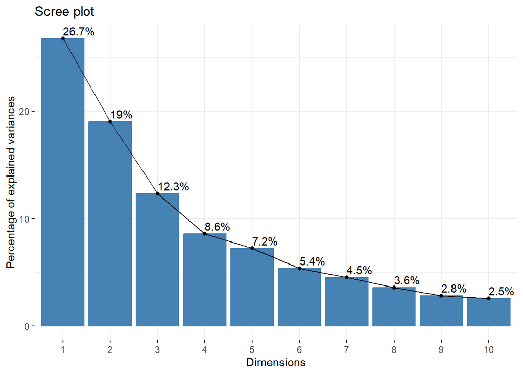

```r
fviz_eig(resAfc, addlabels = T)
```

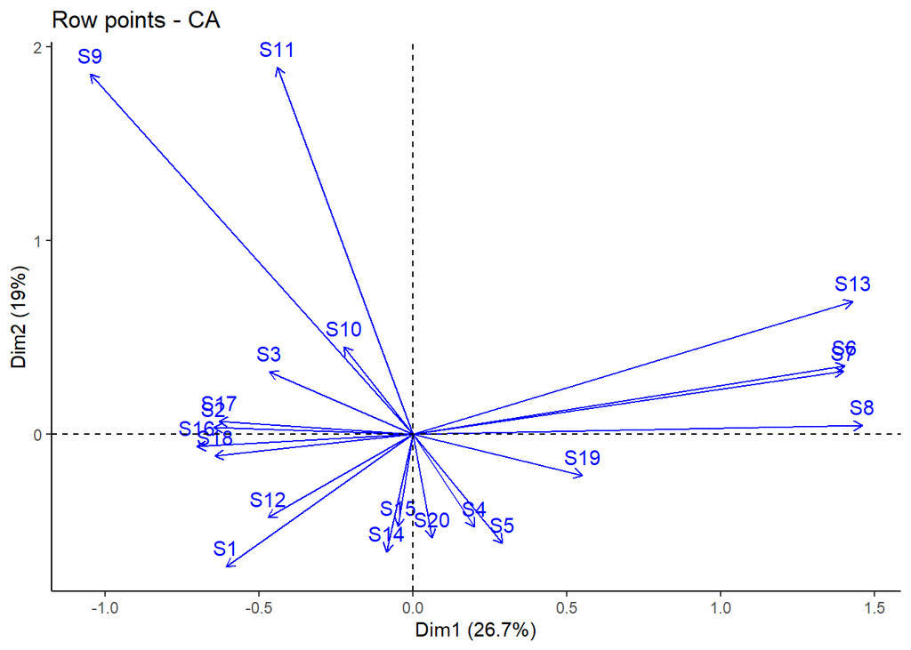

```r
fviz_ca_row(resAfc, geom = c("text","arrow"), col.var = "cos2", axes=1:2) + theme_classic()
```

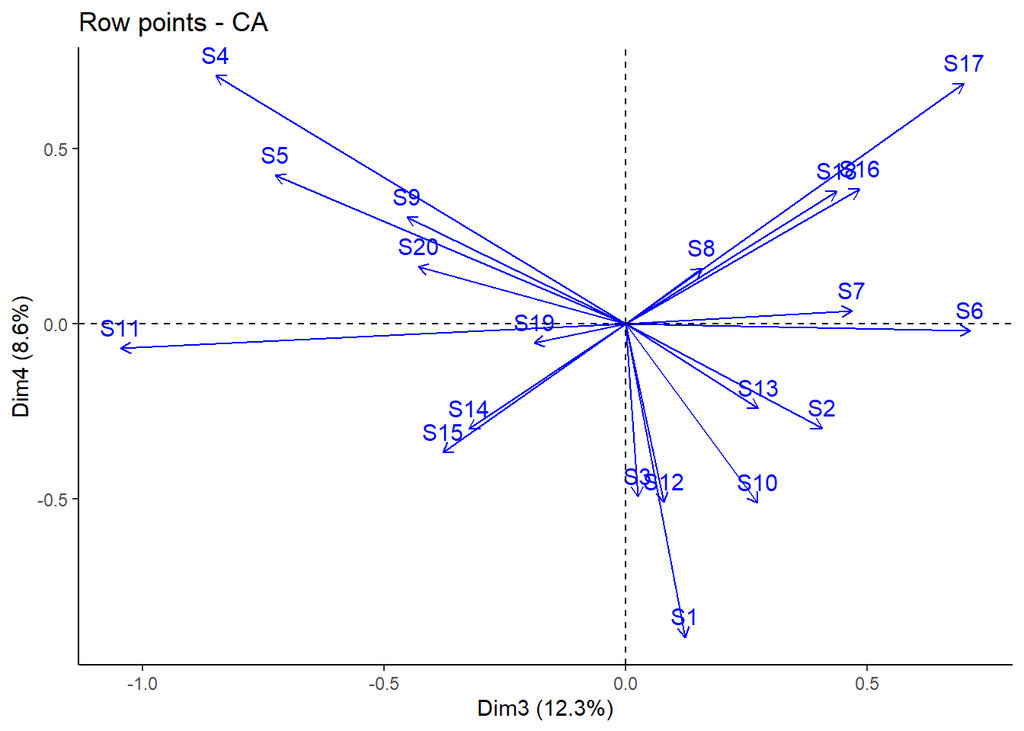

```r
fviz_ca_row(resAfc, geom = c("text","arrow"), col.var = "cos2", axes=3:4) + theme_classic()
```

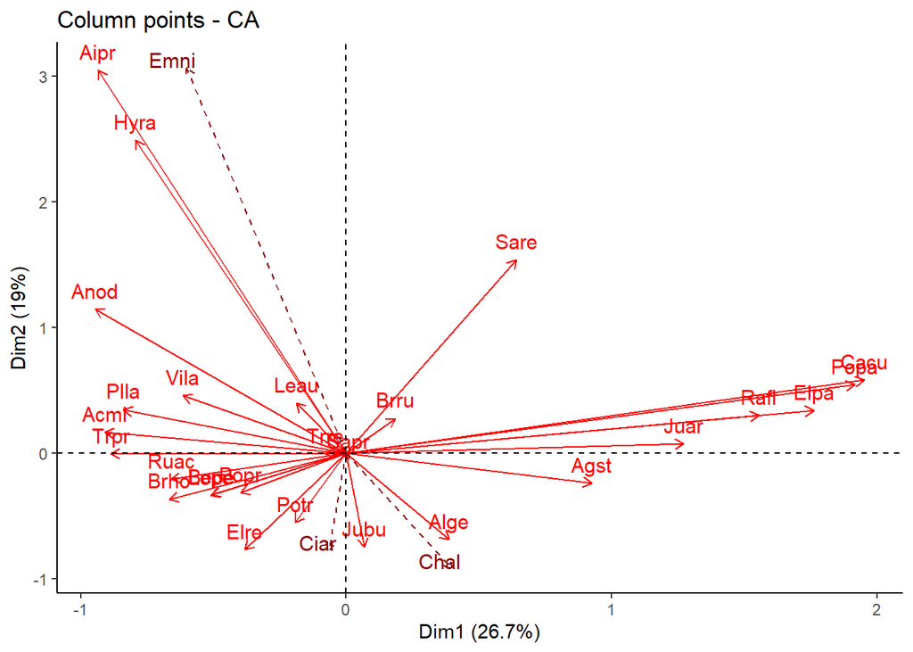

```r
fviz_ca_col(resAfc, geom = c("text","arrow"), col.var = "cos2", axes=1:2) + theme_classic()
```

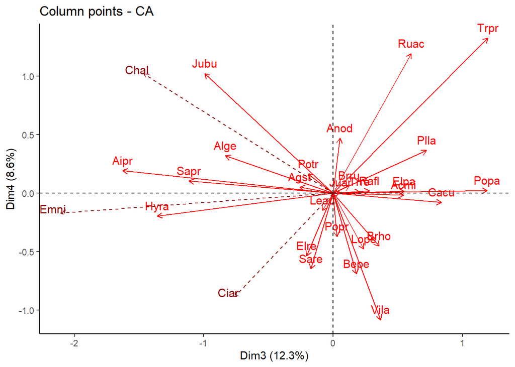

```r
fviz_ca_col(resAfc, geom = c("text","arrow"), col.var = "cos2", axes=3:4) + theme_classic()
```